[OHI Science](http://ohi-science.org) | [Citation policy](http://ohi-science.org/citation-policy/)

# Exploring Sea Level Data

Jamie Afflerbach

9/15/2016

The raw data we downloaded from AVISO is [monthly gridded Mean Sea Level Anomaly data from 1993 - 2015](http://www.aviso.altimetry.fr/en/data/products/sea-surface-height-products/global/msla-mean-climatology.html#c10358). Previously we used a [single data product](http://www.aviso.altimetry.fr/en/data/products/ocean-indicators-products/mean-sea-level/products-images.html) that provided mean sea level trends over time:

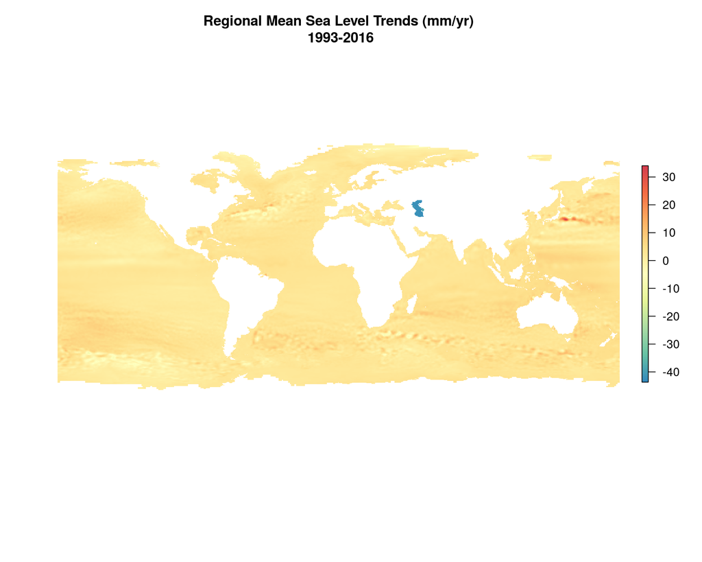

```r
### Define spectral color scheme for plotting maps
cols      = rev(colorRampPalette(brewer.pal(9, 'Spectral'))(255)) # rainbow color scheme

agg_sl <- raster(file.path(dir_anx,'_raw_data/AVISO_slr/d2016/MSL_Map_MERGED_Global_IB_RWT_NoGIA_Adjust.nc'))%>%
          rotate()%>%
          disaggregate(fact=8)

#define projection of the raster before reprojecting
projection(agg_sl) <- "+proj=longlat +datum=WGS84 +ellps=WGS84 +towgs84=0,0,0"

plot(agg_sl,col=cols,box=F,axes=F,main = 'Regional Mean Sea Level Trends (mm/yr)\n 1993-2016')
```

The problem with this dataset is that it doesn’t give us information over time so we can’t use temporal trends to get an idea of how the pressure is changing over time.

So we are exploring using monthly Mean Sea Level Anomaly data to see if we can get at temporal trends.

This downloaded data is in units of meters.

I clipped all data to coastal cells since we are now going to calculate this pressure only along the coast.

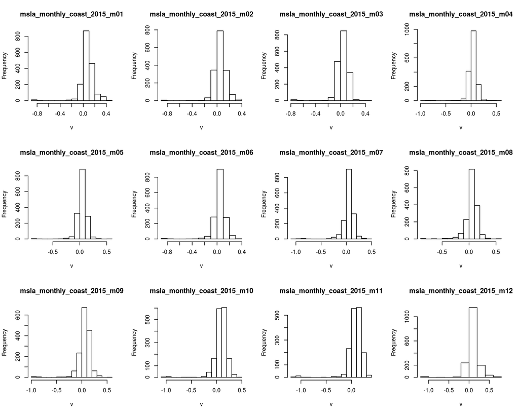

```r
months <- list.files(file.path(dir_git,'globalprep/prs_slr/v2016/int/msla_monthly_coast'),full.names=T)

#look at most recent year (2015)

pres_yr <- months[265:276]%>%stack()

#since the plots at this scale are hard to see, only doing hists of data
hist(pres_yr)
```

Annual means were calculated from the monthly averages.

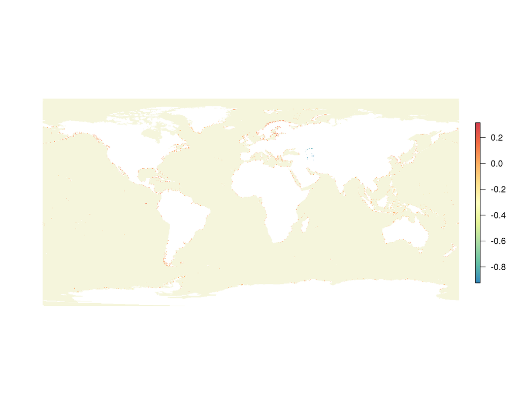

```r
yr_2015 <- raster(file.path(dir_git,'globalprep/prs_slr/v2016/int/msla_annual_mean/rast_msla_annual_2015.tif'))

#get ocean basemap for plot
ocean_wgs <- projectRaster(ocean,yr_2015,progress='text')
plot(ocean_wgs,col='beige',axes=F,legend=F,box=F)
plot(yr_2015,col=cols,box=F,axes=F,add=T, main = 'Mean Sea Level Height (meters)\n 2010')
```

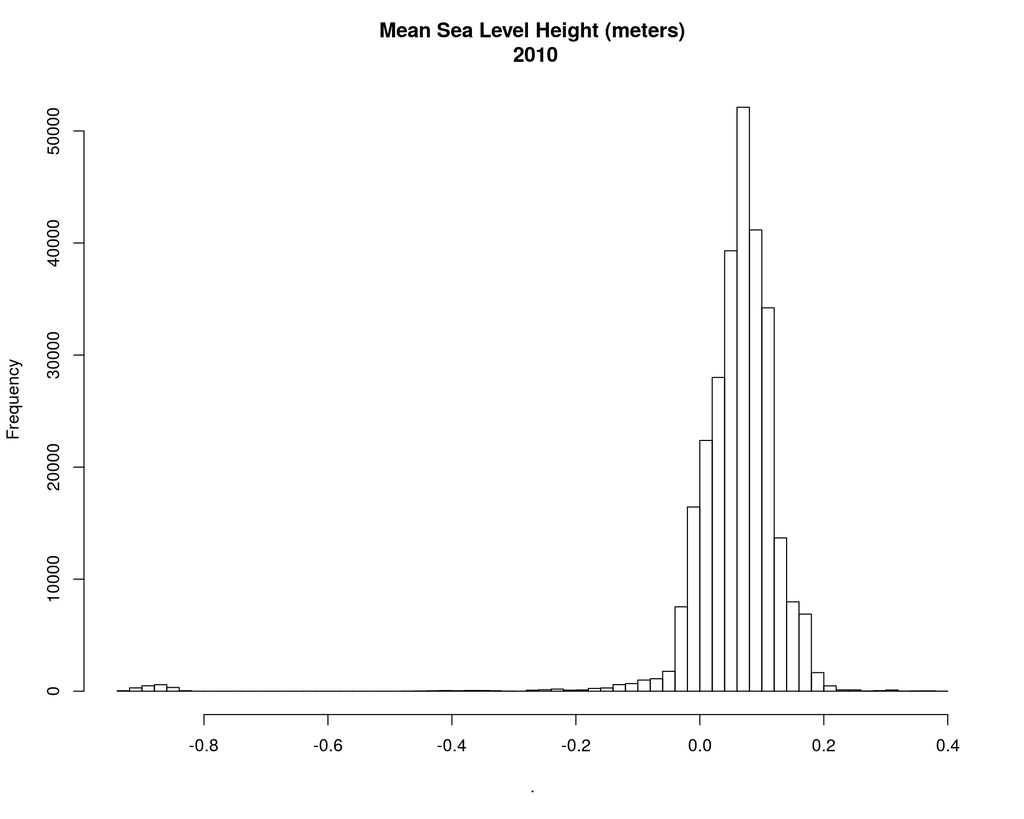

```r
#get a hist of the values

getValues(yr_2015)%>%hist(breaks=50, main = 'Mean Sea Level Height (meters)\n 2010')
```

This data looks wrong at first because of the high numbers. Based on the global aggregate data product, we don’t expect such large numbers in sea level. But confirmation from AVISO and more exploration of this data shows that this is correct.

Here is a static map of **Sea Surface Heights** using the same data, served from a [different site](http://icdc.cen.uni-hamburg.de/1/daten/ocean/ssh-aviso.html) (Integrated Climate Data Center)

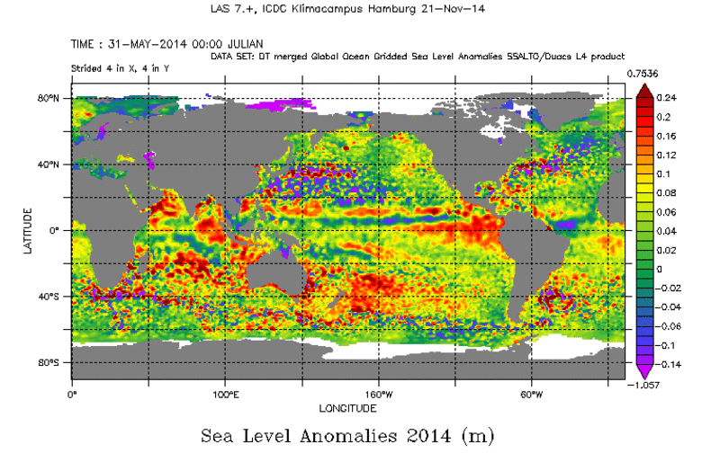

A map of the mean sea level height anomaly for May 31, 2014, taken from the AVISO Ssalto/Duacs two_sat_merged data set - available here at ICDC.

So now I’m thinking that we are simply misconstruing these two datasets. These are not leading to the same thing. Sea surface trends, as shown in the first global map are not the same as looking at Sea Level Anomaly over time.

Since I can’t find any methods or information on how the trends data product is calculated (I’ve emailed a couple times), I started to ask if maybe these two distinct products might come up with similar results once we rescale them and look at the country level.

For OHI I compared mean sea level anomalies in the most recent 5 years with mean sea level anomalies in the 5 historical years (1993-1997)

# Method 1

## Using Mean Sea Level Anomaly to calculate annual means, and then comparing recent to historical reference period

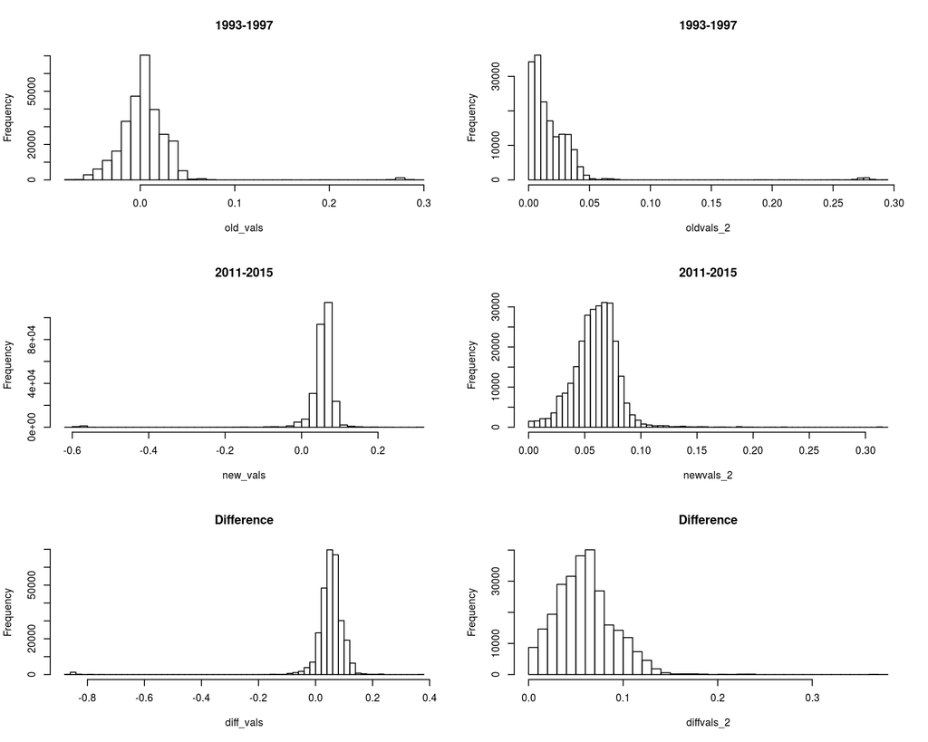

```r
# reference period
old  <- raster(file.path(dir_git,'globalprep/prs_slr/v2016/int/ref_period.tif'))
#current
new  <- raster(file.path(dir_git,'globalprep/prs_slr/v2016/int/current_period.tif'))
#difference
diff <- raster(file.path(dir_git,'globalprep/prs_slr/v2016/int/difference.tif'))

par(mfrow = c(3,2))

old_vals <- getValues(old)
hist(old_vals, breaks = 50, main = '1993-1997')

# look at values greater than 0

oldvals_2 <- old_vals[old_vals>0]
hist(oldvals_2,breaks=50, main = '1993-1997')

new_vals <- getValues(new)
hist(new_vals, breaks = 50, main = '2011-2015')

newvals_2 <- new_vals[new_vals>0]
hist(newvals_2, breaks = 50, main = '2011-2015')

diff_vals <- getValues(diff)
hist(diff_vals, breaks = 50, main = 'Difference')

diffvals_2 <- diff_vals[diff_vals>0]
hist(diffvals_2, breaks = 50, main = 'Difference')
```

Overall we get higher than expected values for sea level anomaly - but I think this is because our expectations of this data product are inaccurate - although I can’t yet figure out how to get from anomaly to trend in a way that makes sense.

Let’s say we use the difference between the two time periods as our OHI pressure layer and rescale to the max, and set all values less than 0 to 0.

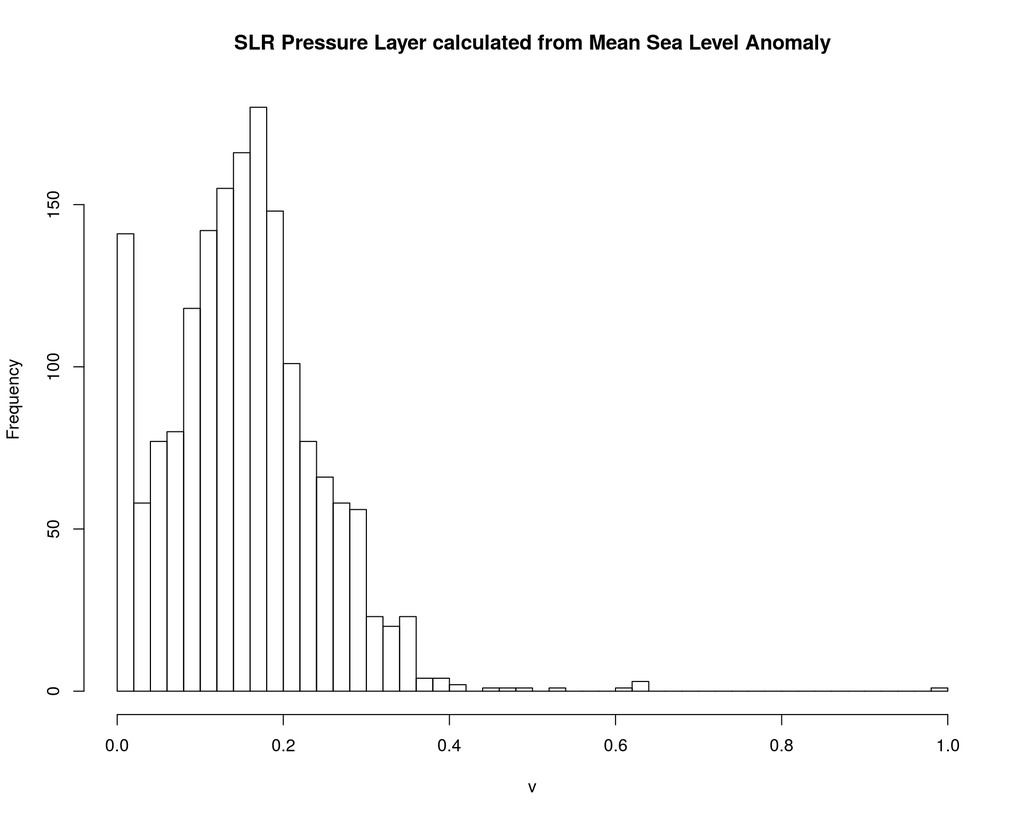

```r
diff_max <- cellStats(diff,stat='max',na.rm=T)
diff_resc <- diff/diff_max
diff_resc[diff_resc<0]=0

hist(diff_resc,breaks=50,main = 'SLR Pressure Layer calculated from Mean Sea Level Anomaly')
```

# Method 2

How does this compare spatially to using the aggregated mean sea level trends data as developed by AVISO.

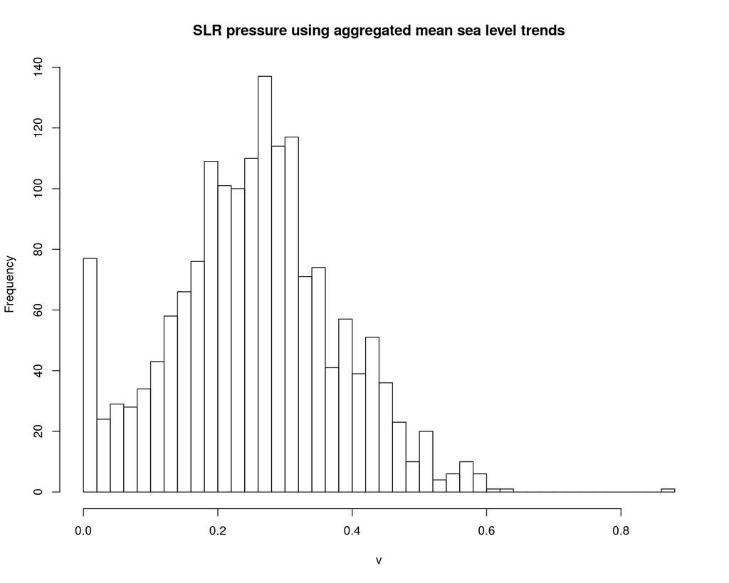

```r
#mask the aggregated data so we only have coastal values
agg_sl_coast <- mask(agg_sl,diff)

#look at coastal values from this aggregated data
fc_max <- cellStats(agg_sl_coast,stat='max',na.rm=T)

agg_sl_coast_resc <- agg_sl_coast/fc_max
agg_sl_coast_resc[agg_sl_coast_resc<0]=0

hist(agg_sl_coast_resc,breaks=50,main = 'SLR pressure using aggregated mean sea level trends')
```

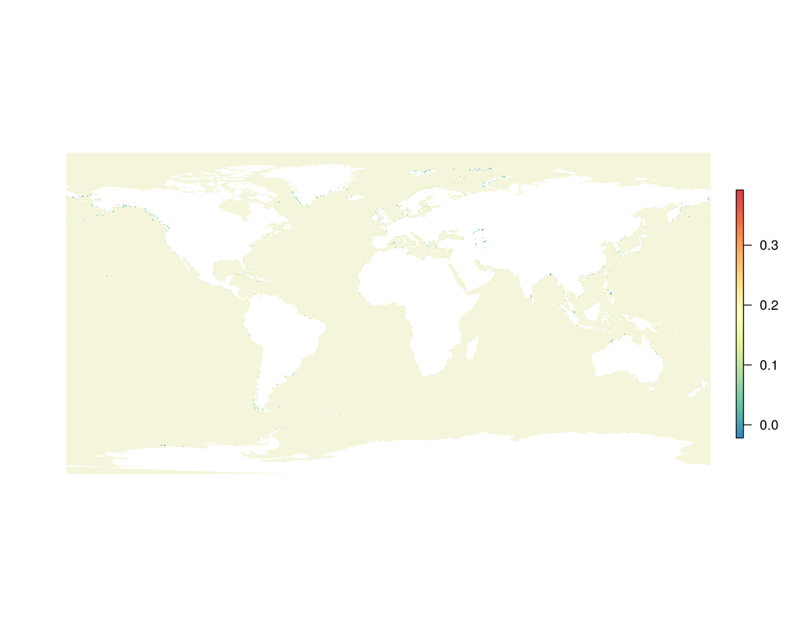

```r
#compare

c <- agg_sl_coast_resc - diff_resc

plot(ocean_wgs,col='beige',axes=F,legend=F,box=F)
plot(c,col=cols,box=F,axes=F,add=T, main = 'Difference between method 1 and 2')
```

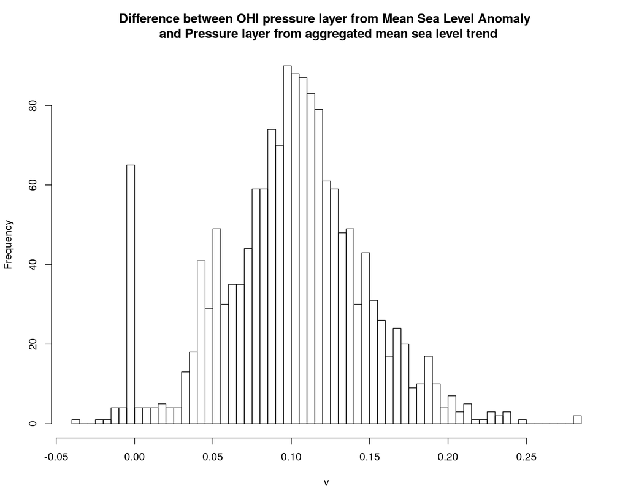

```r
hist(c,breaks=50,main = 'Difference between OHI pressure layer from Mean Sea Level Anomaly \n and Pressure layer from aggregated mean sea level trend')
```